# PEC_2 : Pipeline de Análisis de RNASeq para datos de pacientes con Covid frente a sujetos sanos

Marcos Zamora Amengual

2022-01-09

# 1 Abstract

# 2 Objetivos

El objetivo principal de este estudio es el de **Analizar la respuesta inmune frente a la infeciión por SARS-COV-2**

Para ello:

- Partiremos de tablas de contages de un experimento de RNASeq
- Analizaremos la expresión diferencial de los genes de los 2 grupos experimentales (sanos e infectados por SARS-COV-2)
- Anlizaremos las rutas a las que pertenecen estos genes expresados diferencialmente mediante un análisis de enriquecimiento de genes GO

# 3 Materiales y Métodos

## 3.1 Datos utilizados en el análisis

En este Pipeline se analizan datos de un estudio extraido del repositorio GEO del ncbi, en el que se estudió la influencia de la respuesta inmune frente al SARS-COV-2 en la expresión genética. Este pipeline comienza con los datos del experimento de RNASeq ya alineados con el genema de referencia, ya que partimos de las Tablas de Contages obtenidas tras estos procedimientos. Por ello, el alineamiento de los transcritos no se tiene en cuenta en este análisis

```r
Rawcounts <- read.csv('RawCounts.csv')

# Modificamos el nombre de las filas del data frame para que contenga los nombres de los transcritos que representa en vez del valor numérico de la fila
rownames(Rawcounts) <- Rawcounts$X
```

Esta tabla de contages, que será la información desde la que partamos par realizar el análisis, contiene 34 muestras, la mitad de ellas, de pacientes cotagiados con SARS-COV-2 y la otra mitad de sujetos sanos. Para cada una de las muestras, se analiza la expresión de 60683 transcritos. De esta tabla de contages, nosotros realizaremos una selección de 10 muestras de cada uno de los grupos (Sanos e Infectados con SARS-COV-2). Para ello utilizamos una función propia en la que dividiremos los dos grupos de muestras y seleccionaremos 10 muestras de cada uno de ellos de manera aleatoria

```r
# Aplicamos nuestra fórmula a nuestro set de datos para cada uno de los grupos (HEA y COV)
CovReads <- SelectColumns(Rawcounts, 'COV', 10)

HealthReads <- SelectColumns(Rawcounts, 'HEA', 10)

SelectCounts <- cbind(CovReads, HealthReads)
```

Por último, y antes de comenzar con el análisis, eliminaremos los tránscritos que no están expresados en ninguno de los dos grupos experimentales, ni en los infectados con SARS-COV-2 ni en los sujetos sanos. Para ellos utilizaremos otra función propia que elimina las filas de datos que no contengan al menos más de 3 entradas distintas de 0 para cada uno de los grupos experimentales. Por lo tanto, lo que hará nuestra función será contar el número de 0s por fila y eliminar aquellas filas que contengan 15 ceros o más

```r
FilteredCounts <- CeroFiles(SelectCounts, 14)
```

A este set de datos final en el que tenemos seleccionadas las muestras de cada grupo que analizaremos y los transcritos relevantes para el análisis, le añadiremos un data set anexo que llamaremos SampleInfo y que contendrá 2 columnas. La primera serán los nombres de cada una de las muestras de nuestro data set final, y la segunda será un factor en el que se indicará el grupo al que perteneca cada muestra:

- HEA (muestras de individuos sanos)
- COV (muestras de individuos infectados con SARS-COV-2)

Obtenemos por tanto un set de datos con 20 muestras, divididas equitativamente entre los dos grupos experimental, y 32642 transcritos expresados en el experimento

```r
knitr::kable(head(FilteredCounts))
```

|  | COV178 | COV149 | COV177 | COV179 | COV156 | COV147 | COV152 | COV151 | COV150 | COV157 | HEA184 | HEA063 | HEA183 | HEA185 | HEA070 | HEA062 | HEA066 | HEA065 | HEA064 | HEA071 |
| --- | --- | --- | --- | --- | --- | --- | --- | --- | --- | --- | --- | --- | --- | --- | --- | --- | --- | --- | --- | --- |
| ENSG00000227232 | 3 | 3 | 32 | 2 | 0 | 0 | 2 | 1 | 16 | 2 | 0 | 0 | 1 | 0 | 1 | 0 | 1 | 2 | 1 | 2 |
| ENSG00000278267 | 0 | 2 | 7 | 3 | 2 | 1 | 0 | 3 | 0 | 2 | 12 | 3 | 6 | 5 | 2 | 5 | 9 | 3 | 8 | 6 |
| ENSG00000233750 | 0 | 0 | 0 | 1 | 0 | 1 | 0 | 1 | 1 | 1 | 0 | 0 | 1 | 1 | 0 | 0 | 0 | 1 | 1 | 1 |
| ENSG00000268903 | 12 | 4 | 13 | 7 | 19 | 10 | 10 | 33 | 8 | 8 | 5 | 14 | 6 | 7 | 6 | 18 | 9 | 8 | 4 | 14 |
| ENSG00000269981 | 6 | 5 | 16 | 2 | 24 | 1 | 1 | 23 | 7 | 5 | 7 | 2 | 4 | 1 | 5 | 9 | 6 | 5 | 8 | 14 |
| ENSG00000241860 | 1 | 2 | 5 | 3 | 5 | 0 | 2 | 7 | 1 | 3 | 6 | 7 | 2 | 0 | 1 | 2 | 1 | 0 | 2 | 6 |

## 3.2 Normalización de los Datos

```r
library(limma)
library(edgeR)

DGECounts <- DGEList(FilteredCounts)

DGECounts_Norm <- calcNormFactors(DGECounts)
```

## 3.3 Visualización de los datos normalizados

Una vez tenemos los datos ya seleccionados, filtrados y normalizados, podemos visualizarlos para estudiar a gran escala su distribución y ver si son comparables y si esperamos ver alguna diferencia entre los grupos experimentales o si existen otras diferencias en los datos que no se correpondan con estos grupos seleccionados y que se puedan deber a otras causas.

En primer lugar, vamos a realizar un boxplot de los logaritmos de los datos normalizados para ver si todas las muestras presentan una media similar y por tanto para comprobar si las muestras son comparables entre sí. Podemos comprobar en el boxplot que las medidas de todos los grupos se centran muy claramente sobre la media global (línea roja)

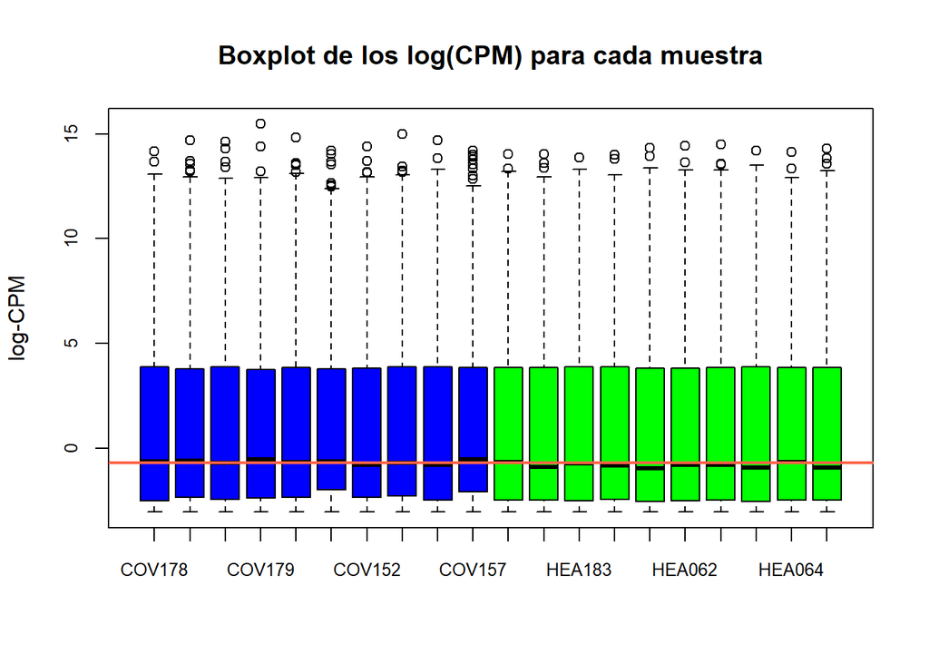

Para llevar a cabo este estudio, debemos calcular en primer lugar las distancias que existen entre las distintas muestras, y una vez obtenidas estas distancia, podemos mostrarlas utilizando un gráfico de puntos

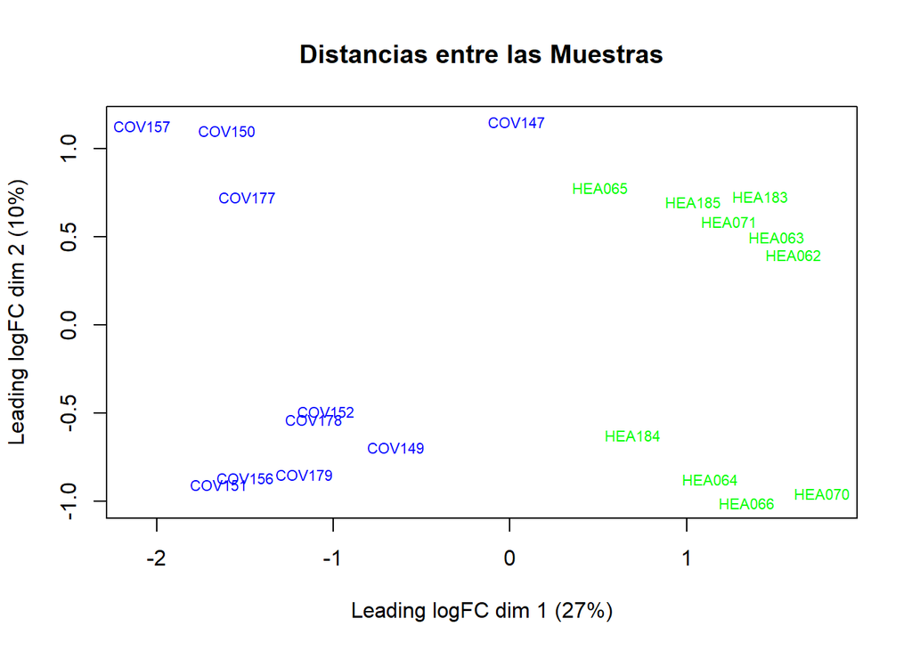

```r
# Cálculo de las distancias entre muestras
sampleDists <- dist(t(DGECounts_Log))

# Distancias entre muestras graficadas
plotMDS(DGECounts_Log,col=col.status, main="Distancias entre las Muestras", cex=0.7)
```

Se puede comprobar claramente como la distribución de las muestras se divide en dos grupos, uno a la izquierda del gráfico, compuesto por las muestras correspondientes al grupo COV(pacientes con Covid) y otro grupo a la derecha, con las muestras correspondientes al grupo HEA(sujetos sanos). Esto nos confirma que existen diferencias significativas entre las muestras de los grupos y que por lo tanto es probable que obtengamos resultados que confirmen estas diferencias. Podemos graficar este resultado de nuevo pero esta vez utilizando un dendograma que nos muestre como se agrupan nuestras muestras

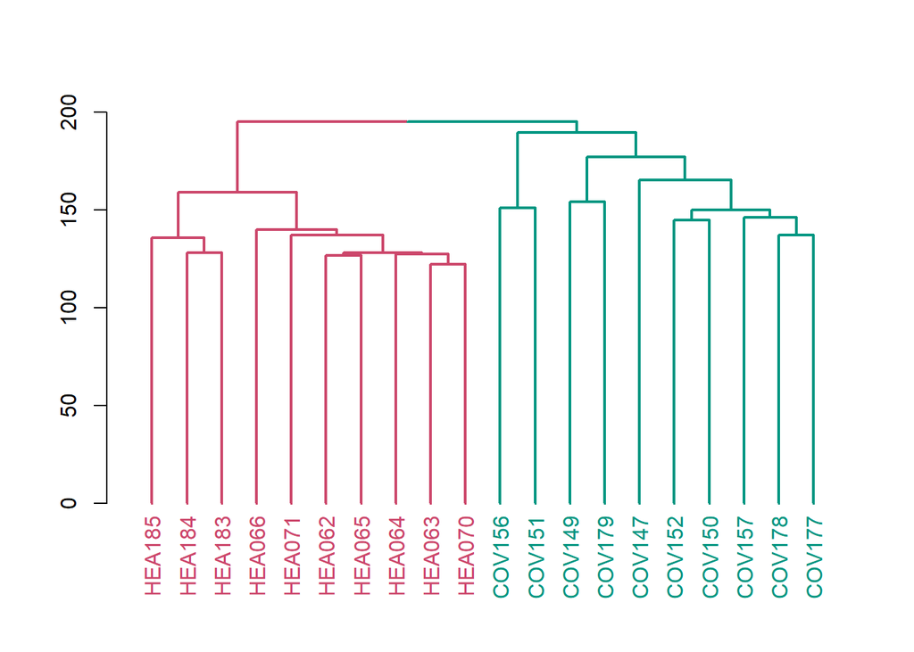

## 3.4 Análisis de Expresión Diferencial

Para realizar el análisis propiamente dicho, vamos a utilizar el paquete limma-Voom para realizar el análisis de los genes expresados diferencialmente. Para ello construiremos una matriz de modelo en el que dividiremos las muestras entre los distintos grupos experimentales para poder analizar las diferencias entre ambos. También realizamos una matriz de contrastes en la que indicaremos las comparaciones que realizaremos entre los distintos grupos experimentales

```r
design  <-  model.matrix(~0+SampleInfo$Status)
colnames(design) <- c("COV", "HEA")
rownames(design) <- SampleInfo$ShortName

cont.matrix <- makeContrasts(CovVsHealthy= COV - HEA, levels=design)

cont.matrix
```

```
##       Contrasts
## Levels CovVsHealthy
##    COV            1
##    HEA           -1
```

Utilizaremos estas matrices para generar la toptable que contendrá los genes expresados diferencialmente entre los dos grupos experimentales que hemos comparado. Para discernir entre los genes expresados diferencialmente y los no expresados diferencialmente, utilizaremos la función *eBayes* que utiliza un algoritmo similar al de naive Bayes para clusterizar los genes expresados diferencialmente de los genes que no están infra o sobreexpresados

```r
VoomCounts <- voom(DGECounts_Norm, design)

fit <- lmFit(VoomCounts)
fit.cont <- contrasts.fit(fit, cont.matrix)
fit.cont <- eBayes(fit.cont)

toptab_CovVsHEA <- topTable(fit.cont,sort.by="p", number=nrow(fit.cont))
head(toptab_CovVsHEA)
```

[output not shown]

Podemos mostrar los tránscritos que presentan una mayor expresión diferencial entre los grupos experimentales utilizando un gráfico del tipo volcán en el que se pueden observar los genes expresados diferencialmente entre los grupos. Vamos a remarcar los 5 genes que presentan una expresión diferencial mayor

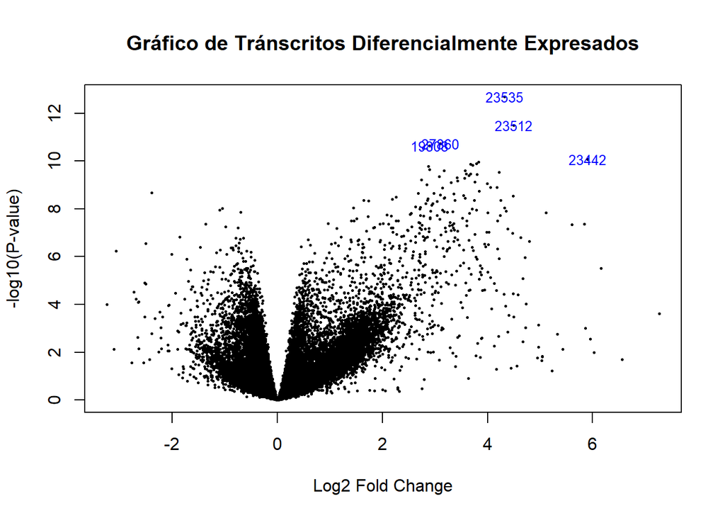

También podemos hacernos una idea del número de tránscritos con expresión diferencial si mostramos en una tabla aquellos que estan infraexpresados, sobreexpresados y los tránscritos que no se ven afectados

```
##        CovVsHealthy
## Down             22
## NotSig        32131
## Up              489
```

Estos 511 transcritos que presentan una expresión diferencial entre los grupos experimentales se pueden observar en un mapa de calor para ver como es esta expresión diferencial y para ver en que grupos aparecen los genes sobreexpresados y en cuales los infraexpresados. Podemos ver en el mapa de calor inferior que la mayoría de los genes sobreexpresados se encuentran en el grupo de pacientes con COVID, lo que nos podría indicar que hay una respuesta inmune frente al patógeno que activa o sobreexpresa algunos genes que no son necesarios si no hay una infección vírica

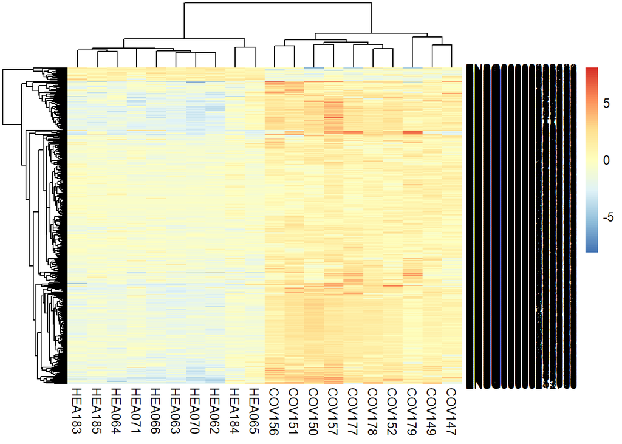

## 3.5 Análisis de significación biológica

Vamos a seleccionar estos 489 genes sobreexpresados para analizar de que rutas biológicas forman parte y poder estudiar la significación biológica de esta sobreexpresión y comprobar si se debe a una respuesta inmune estimulada por la infección provocada por el SARS-COV-2. Para ello vamos a realizar un análisis de significación biológica utilizando la base de datos GO en la que podemos encontrar los transcritos sobreeexpresados y sus anotaciones correspondientes a las rutas metabólicas de las que forman parte.

```r
library(clusterProfiler)
library(org.Hs.eg.db)
ego <- enrichGO(gene = selectedEntrezsUP,
                universe = allEntrezs,
                keyType = "ENSEMBL",
                OrgDb = org.Hs.eg.db,
                ont = "BP",
                pAdjustMethod = "BH",
                qvalueCutoff = 0.05,
                readable = TRUE)
```

# 4 Resultados

Obtenemos como resultado un listado de todos los genes que se encuentran sobreexpresados en los pacientes con SARS-COV-2 frente a los sujetos sanos, unidos estos a las categorías GO de cada uno de ellos. Gracias a esto podemos analizar que categorías se ven más sobreexpresados y podemos etudiar a que se deben estas sobreexpresiones.

Podemos mostrar estos resultados que hemos obtenido de varias maneras, utilizando distintos gráficos para mostrar las rutas metabólicas sobreexpresadas. En el gráfico inferior por ejemplo podemos observar las 8 rutas metabólicas que presentan una mayor sobreexpresión dentro del grupo de pacientes infectados. Podemos observar que la mayoría de las rutas estan relacionados con procesos metabólicos de defensa como pueden ser la producción de inmunoglobinas o la fagocitosis

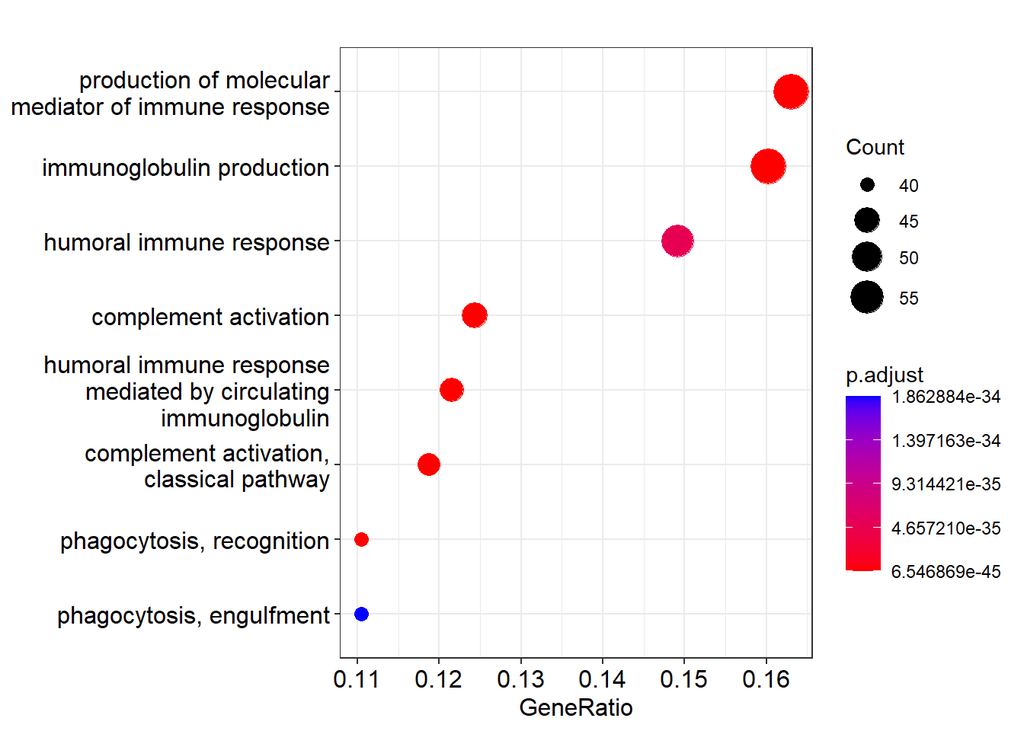

# 5 Discusión

En este análisis hemos podido realizar todos los pasos de un ánalisis bioinformático de RNASeq, desde el preprocesado y la normalización de los datos a partir de tablas de contages hasta el ánalisis de expresión diferencial y de significación biológica de los resultados finales. Esto nos ha permitido ver a gran escala como se llevan a cabo este tipo de análisis y que paquetes existen para llevarlos a cabo

Aunque en general, este estudio nos ha permito comprender el proceso de anáisis de RNASeq a gran escala, el no conocer el estudio de partido, y el no haber llevado a cabo el alineamiento con el genoma de referencia para obtener la tabla de contages por nuestra cuenta son los dos puntos principales en los que considero que hemos tenido una mayor limitación y nos han permitido ser menos flexibles con nuestros análisi finales

# 6 Apéndice

```r
# Pipeline de Análisis de Datos de RNASeq

# Paquetes, datos y directorio utilizados

library(limma)
library(edgeR)
library(dendextend)
library(pheatmap)
library(clusterProfiler)
library(enrichplot)

setwd('D:/Docs/Masteres/Master en Bioinformática y Bioestadística/Tercer Semestre/M0.157 - Análisis de datos ómicos/PEC_02')

Rawcounts <- read.csv('RawCounts.csv')

# Función para separar data sets en función de los grupos y el número de muestras deseadas

SelectColumns <- function(df, Tpatient, size){

  set.seed(123)

  df <- df[ , grepl(Tpatient , names( df ) )]

  sample <- sample(c(1:ncol(df)), size = size, replace = F)

  sampledf <- df[sample]

  return(sampledf)
}

# Separación de grupos

CovReads <- SelectColumns(Rawcounts, 'COV', 10)

HealthReads <- SelectColumns(Rawcounts, 'HEA', 10)

SelectCounts <- cbind(CovReads, HealthReads)

# Modificamos el nombre de las filas del set de datos

rownames(SelectCounts) <- Rawcounts$X

head(SelectCounts, 10)

# Función que elimina las filas que contienen mas de un número fijado de 0s

CeroFiles <- function(df, MaxNumCero){

  v <- c()

    for(row in 1:nrow(df)){

      i <- df[row, ]

       count <- 0

       for(number in i){
         if(number == 0){
           count <- count + 1
           }
       }
       if(count > MaxNumCero){
         v <- append(v, row)
         }
    }
  df <- df[-v,]
  return(df)
   }

FilteredCounts <- CeroFiles(SelectCounts, 14)

# Generamos un set de datos adicional con la información de a que grupo pertenece cada una de las muestras

SampleInfo <- data.frame(colnames(FilteredCounts), c(rep('COV', 10), rep('HEA', 10)))

colnames(SampleInfo) <- c('ShortName', 'Status')

SampleInfo$Status <- factor (SampleInfo$Status)

SampleInfo

# Normalizamos los datos utilizando la función TMM

DGECounts <- DGEList(FilteredCounts)

DGECounts$samples

DGECounts_Norm <- calcNormFactors(DGECounts)

DGECounts_Log <- cpm(DGECounts_Norm, log=TRUE)

# Boxplot de la media normalizada de los distintos grupos

col.status <- c("blue","green")[SampleInfo$Status]

boxplot(DGECounts_Log, ylab="Log2-CPM",las=2, xlab="", cex.axis=0.8, col = col.status, main="Boxplot de los logCPM (datos normalizados)")

abline(h=median(DGECounts_Log), col="blue")

# Cálculo de las distancias entre muestras

sampleDists <- dist(t(DGECounts_Log))

# Dendograma de las distancias entre muestras

hc <- hclust(sampleDists)

dend <-as.dendrogram(hc)

dend <- dend %>%
  color_branches(k = 2) %>%
  set("branches_lwd", c(2,2)) %>%
  set("branches_lty", c(1,1))

dend <- color_labels(dend, k = 2)

plot(dend)

# Distancias entre muestras graficadas

plotMDS(DGECounts_Log,col=col.status, main="Status", cex=0.7)

# Análisis de expresión diferencial con limma-voom

design  <-  model.matrix(~0+SampleInfo$Status)
colnames(design) <- c("COV", "HEA")
rownames(design) <- SampleInfo$ShortName
design

cont.matrix <- makeContrasts(CovVsHealthy= COV - HEA, levels=design)

cont.matrix

VoomCounts <- voom(DGECounts_Norm, design)

VoomCounts

fit <- lmFit(VoomCounts)
fit.cont <- contrasts.fit(fit, cont.matrix)
fit.cont <- eBayes(fit.cont)

toptab_CovVsHEA <- topTable(fit.cont,sort.by="p", number=nrow(fit.cont))
head(toptab_CovVsHEA)

volcanoplot(fit.cont,highlight=10, main="CovVsHEA")

write.csv(toptab_CovVsHEA, "toptab_CovVsHEA.csv")

summa.fit <- decideTests(fit.cont, p.value = 0.05, lfc = 2)
summary(summa.fit)


topGenes <- rownames(subset(toptab_CovVsHEA, (abs(logFC)> 2) & (adj.P.Val < 0.05)))
length(topGenes)
mat  <- DGECounts_Log[topGenes, SampleInfo$ShortName]
mat  <- mat - rowMeans(mat)

pheatmap(mat)

# Análisis de significación biológica con GOSeq

topTab<- toptab_CovVsHEA
head(topTab)

allEntrezs <- rownames(topTab)
selectedEntrezsUP <- rownames(subset(topTab, (logFC> 2) & (adj.P.Val < 0.05)))
length(allEntrezs); length(selectedEntrezsUP)

allEntrezs


ego <- enrichGO(gene = selectedEntrezsUP,
                universe = allEntrezs,
                keyType = "ENSEMBL",
                OrgDb = org.Hs.eg.db,
                ont = "BP",
                pAdjustMethod = "BH",
                qvalueCutoff = 0.05,
                readable = TRUE)

head(ego)
ego_results <- data.frame(ego)
write.csv(ego_results, "clusterProfiler_ORAresults_UpGO.csv")

# Visualización de los resultados del análisis de enriquecimiento

dotplot(ego, showCategory=9)

goplot(ego, showCategory=5, cex=0.5)

cnetplot(ego)


ego_sim <- pairwise_termsim(ego)
emapplot(ego_sim, cex_label_category=0.5)
```